# Association Between Sedentary Behavior and Metabolic Dysfunction-Associated Steatotic Liver Disease in U.S. Adults: A Cross-Sectional Analysis of NHANES 2017–2020

Basic Descriptive Statistics

Guilherme da Silva Ferreira

2026-09-12 (YYYY-MM-DD)

## Overview

This document was created in R using R Markdown. Markdown is a simple formatting syntax for authoring HTML, PDF, and MS Word documents. For more details on using R Markdown, visit http://rmarkdown.rstudio.com.

### Variable Naming Convention

- **UPPERCASE variables:** Retain their original NHANES variable names (with missing value codes converted to `NA` and skip patterns handled appropriately).
- **lowercase variables:** Represent derived variables created during processing (e.g., `smoker`).

### Key Resources & Documentation

- [NHANES Continuous Data Files (CDC)](https://wwwn.cdc.gov/nchs/nhanes/search/default.aspx)
- [The Epidemiologist R Handbook](https://www.epirhandbook.com/en/)
- [CDC NHANES R Tutorial Examples](https://wwwn.cdc.gov/nchs/data/tutorials/module3_examples_R.r)
- [STC Library Reference](https://libstc.cc/#/stc/nid:6e7ka238xj6qcuyf7dkdkuyfo)
- [R for Medical Public Health Data Analysis](https://bookdown.org/rwnahhas/RMPH/intro.html)

# 1. Loading and Installing Required Packages

```r
# Clear workspace
rm(list = ls())

# Define required packages
required_packages <- c("survey", "tidyverse", "skimr", "lmtest", "gt", "gtsummary", "broom", "here","rio", "moments", "naniar")

# Install missing packages automatically
for (pkg in required_packages) {
  if (!requireNamespace(pkg, quietly = TRUE)) {
    install.packages(pkg, dependencies = TRUE)
  }
}

# Load all packages silently
suppressPackageStartupMessages({
  invisible(lapply(required_packages, library, character.only = TRUE))
})

# Display current R version
cat("R Version:", as.character(getRversion()), "\n")
```

```
## R Version: 4.4.3
```

```r
# Load required libraries
library(survey)
library(tidyverse)
library(gtsummary)
library(gt)
library(skimr)
library(rio)
library(here)
library(moments)
library(naniar)


# Display loaded package versions
cat("R package versions:\n")
```

```
## R package versions:
```

```r
for (p in required_packages) {
  cat(p, ": ", as.character(packageVersion(p)), "\n")
}
```

```
## survey :  4.4.2
## tidyverse :  2.0.0
## skimr :  2.1.5
## lmtest :  0.9.40
## gt :  0.11.1
## gtsummary :  2.1.0
## broom :  1.0.7
## here :  1.0.1
## rio :  1.2.3
## moments :  0.14.1
## naniar :  1.1.0
```

```r
# Configure survey package options # Specify how the survey package should handle strata containing only one # Primary Sampling Unit (PSU).

options(survey.lonely.psu = "adjust")
options(survey.adjust.domain.lonely = TRUE)
```

# 2. Loading Design and Data Frame

```r
load("df_weighted.RData")
summary(svy_design_subset)
```

```
## Stratified 1 - level Cluster Sampling design (with replacement)
## With (49) clusters.
## subset(svy_design, RIDAGEYR >= 20 & LUAXSTAT == 1 & !is.na(LUXCAPM) &
##     !is.na(masld_288) & !is.na(PAD680) & (RIDEXPRG != 1 | is.na(RIDEXPRG)) &
##     (alcohol_use != "Heavy Drinker" | is.na(alcohol_use)) & (LBDHBG !=
##     1 | is.na(LBDHBG)) & (LBXHCR != 1 | is.na(LBXHCR)) & (nafld_induced_agents ==
##     FALSE | is.na(nafld_induced_agents)))
## Probabilities:
##      Min.   1st Qu.    Median      Mean   3rd Qu.      Max.
## 1.349e-06 1.353e-05 2.622e-05 3.294e-05 4.423e-05 2.080e-04
## Stratum Sizes:
##            149 150 151 152 153 154 155 156 157 158 159 160 161 162 163 164 165
## obs        120 124 138 123 104 130 124 217 127 136 155  68 125 120 105 143 121
## design.PSU   2   2   2   2   2   2   2   3   2   2   2   2   2   2   2   2   2
## actual.PSU   2   2   2   2   2   2   2   3   2   2   2   2   2   2   2   2   2
##            166 167 168 169 170 171 172
## obs        113  98 132 124 134 111 142
## design.PSU   2   2   2   2   2   2   2
## actual.PSU   2   2   2   2   2   2   2
## Data variables:
##  [1] "SEQN"                    "WTSAFPRP"
##  [3] "SDMVPSU"                 "RIAGENDR"
##  [5] "SDMVSTRA"                "RIDAGEYR"
##  [7] "ridageyr_cat"            "race_1"
##  [9] "race_2"                  "race_3"
## [11] "education"               "INDFMPIR"
## [13] "indfmpir_cat"            "BMXWAIST"
## [15] "BMXBMI"                  "LUXSMED"
## [17] "sbp"                     "dbp"
## [19] "LUXCAPM"                 "hsi"
## [21] "fli"                     "nafld_288"
## [23] "nafld_248"               "nafld_302"
## [25] "masld_288"               "masld_248"
## [27] "masld_302"               "hepatic_fibrosis"
## [29] "LBXTC"                   "LBDHDD"
## [31] "LBXGLU"                  "LBXIN"
## [33] "LBXGH"                   "LBDLDL"
## [35] "LBXTR"                   "LBXSATSI"
## [37] "LBXSASSI"                "LBXSGTSI"
## [39] "homair"                  "PAD680"
## [41] "pad680_hours"            "work_activity"
## [43] "transportation_activity" "recreational_activity"
## [45] "mvpa"                    "mvpa_category"
## [47] "pa_met"                  "ast_alt"
## [49] "smoking"                 "alcohol_use"
## [51] "overweight_obese"        "diabetes"
## [53] "htn"                     "hypertrigly"
## [55] "low_hdl"                 "kcal_mean"
## [57] "kcal_mean_cat"           "tprot_adj"
## [59] "tcarb_adj"               "tsugar_adj"
## [61] "tfat_adj"                "tsatfat_adj"
## [63] "tunsatfat_adj"           "dysglycaemia_dm2"
## [65] "cvd"                     "metabolic_syndrome"
## [67] "sb"                      "dyslipidemia"
```

# 3. Data Visualization

```r
# Counting Missing Data

missing_summary <- skim(svy_design_subset$variables) %>%
  select(
    Variable = skim_variable,
    `Missing Data (n)` = n_missing,
    `Complete Rate (%)` = complete_rate
  ) %>%
  mutate(`Complete Rate (%)` = round(100 * `Complete Rate (%)`, 2)) %>%
  arrange(desc(`Complete Rate (%)`))

export(missing_summary, here("Tables", "missing_data.csv"))
missing_summary
```

```
## # A tibble: 68 × 3
##    Variable     `Missing Data (n)` `Complete Rate (%)`
##    <chr>                     <int>               <dbl>
##  1 RIAGENDR                      0                 100
##  2 ridageyr_cat                  0                 100
##  3 race_1                        0                 100
##  4 race_2                        0                 100
##  5 race_3                        0                 100
##  6 nafld_288                     0                 100
##  7 nafld_248                     0                 100
##  8 nafld_302                     0                 100
##  9 masld_288                     0                 100
## 10 masld_302                     0                 100
## # ℹ 58 more rows
```

```r
# Counting complete cases

naniar::pct_complete_case(svy_design_subset$variables)
```

```
## [1] 45.18787
```

```r
skim(svy_design_subset$variables)
```

Data summary

| Name | svy_design_subset$variabl… |
| --- | --- |
| Number of rows | 3034 |
| Number of columns | 68 |
| _______________________ |  |
| Column type frequency: |  |
| factor | 28 |
| numeric | 40 |
| ________________________ |  |
| Group variables | None |

**Variable type: factor**

| skim_variable | n_missing | complete_rate | ordered | n_unique | top_counts |
| --- | --- | --- | --- | --- | --- |
| RIAGENDR | 0 | 1.00 | FALSE | 2 | 2: 1580, 1: 1454 |
| ridageyr_cat | 0 | 1.00 | FALSE | 2 | 0: 1982, 1: 1052 |
| race_1 | 0 | 1.00 | FALSE | 4 | 3: 999, 1: 729, 4: 726, 5: 580 |
| race_2 | 0 | 1.00 | FALSE | 5 | 3: 999, 1: 729, 4: 726, 6: 418 |
| race_3 | 0 | 1.00 | FALSE | 2 | 1: 2035, 3: 999 |
| education | 2 | 1.00 | FALSE | 2 | 3: 1750, 1: 1282 |
| indfmpir_cat | 400 | 0.87 | FALSE | 2 | 1: 2167, 0: 467 |
| nafld_288 | 0 | 1.00 | FALSE | 2 | 0: 1964, 1: 1070 |
| nafld_248 | 0 | 1.00 | FALSE | 2 | 1: 1786, 0: 1248 |
| nafld_302 | 0 | 1.00 | FALSE | 2 | 0: 2183, 1: 851 |
| masld_288 | 0 | 1.00 | FALSE | 2 | 0: 1965, 1: 1069 |
| masld_248 | 2 | 1.00 | FALSE | 2 | 1: 1774, 0: 1258 |
| masld_302 | 0 | 1.00 | FALSE | 2 | 0: 2183, 1: 851 |
| hepatic_fibrosis | 0 | 1.00 | FALSE | 2 | 0: 2942, 1: 92 |
| mvpa_category | 16 | 0.99 | FALSE | 2 | ≥15: 1925, <15: 1093 |
| smoking | 2 | 1.00 | FALSE | 3 | 0: 1841, 1: 714, 2: 477 |
| alcohol_use | 147 | 0.95 | FALSE | 3 | Non: 1992, For: 612, Nev: 283, Hea: 0 |
| overweight_obese | 22 | 0.99 | FALSE | 2 | 1: 2511, 0: 501 |
| diabetes | 0 | 1.00 | FALSE | 2 | 0: 2370, 1: 664 |
| htn | 174 | 0.94 | FALSE | 2 | 1: 1631, 0: 1229 |
| hypertrigly | 39 | 0.99 | FALSE | 2 | 0: 1883, 1: 1112 |
| low_hdl | 39 | 0.99 | FALSE | 2 | 0: 1599, 1: 1396 |
| kcal_mean_cat | 220 | 0.93 | FALSE | 2 | 1: 1569, 0: 1245 |
| dysglycaemia_dm2 | 0 | 1.00 | FALSE | 2 | 1: 2154, 0: 880 |
| cvd | 0 | 1.00 | FALSE | 2 | 0: 2708, 1: 326 |
| metabolic_syndrome | 1103 | 0.64 | FALSE | 2 | 1: 1777, 0: 154 |
| sb | 0 | 1.00 | FALSE | 2 | 0: 2182, 1: 852 |
| dyslipidemia | 39 | 0.99 | FALSE | 2 | 1: 2093, 0: 902 |

**Variable type: numeric**

| skim_variable | n_missing | complete_rate | mean | sd | p0 | p25 | p50 | p75 | p100 | hist |
| --- | --- | --- | --- | --- | --- | --- | --- | --- | --- | --- |
| SEQN | 0 | 1.00 | 117144.09 | 4498.72 | 109271.00 | 113278.25 | 117164.50 | 121044.00 | 124821.00 | ▇▇▇▇▇ |
| WTSAFPRP | 0 | 1.00 | 64589.30 | 74026.24 | 4808.07 | 22609.03 | 38139.20 | 73926.21 | 741259.19 | ▇▁▁▁▁ |
| SDMVPSU | 0 | 1.00 | 1.54 | 0.55 | 1.00 | 1.00 | 2.00 | 2.00 | 3.00 | ▇▁▇▁▁ |
| SDMVSTRA | 0 | 1.00 | 160.35 | 6.92 | 149.00 | 155.00 | 160.00 | 166.00 | 172.00 | ▆▇▅▆▇ |
| RIDAGEYR | 0 | 1.00 | 50.14 | 17.21 | 20.00 | 35.00 | 51.00 | 64.00 | 80.00 | ▇▇▇▇▆ |
| INDFMPIR | 400 | 0.87 | 2.66 | 1.61 | 0.00 | 1.23 | 2.38 | 4.27 | 5.00 | ▅▇▅▃▇ |
| BMXWAIST | 81 | 0.97 | 100.10 | 16.71 | 63.20 | 88.10 | 98.70 | 110.70 | 173.10 | ▃▇▅▁▁ |
| BMXBMI | 30 | 0.99 | 29.78 | 7.22 | 15.00 | 24.78 | 28.60 | 33.50 | 86.20 | ▇▆▁▁▁ |
| LUXSMED | 0 | 1.00 | 5.70 | 4.13 | 1.60 | 4.10 | 5.00 | 6.10 | 75.00 | ▇▁▁▁▁ |
| sbp | 259 | 0.91 | 123.40 | 18.80 | 78.67 | 110.00 | 120.33 | 133.00 | 214.00 | ▂▇▃▁▁ |
| dbp | 259 | 0.91 | 74.09 | 11.21 | 41.33 | 66.33 | 73.33 | 81.00 | 137.67 | ▁▇▃▁▁ |
| LUXCAPM | 0 | 1.00 | 264.86 | 61.80 | 100.00 | 220.00 | 263.00 | 307.75 | 400.00 | ▁▅▇▆▃ |
| hsi | 105 | 0.97 | 40.27 | 7.52 | 22.96 | 35.07 | 38.88 | 43.97 | 97.84 | ▇▇▁▁▁ |
| fli | 152 | 0.95 | 52.32 | 32.82 | 0.63 | 20.82 | 52.25 | 84.97 | 100.00 | ▇▅▅▅▇ |
| LBXTC | 48 | 0.98 | 184.46 | 40.86 | 76.00 | 155.00 | 180.00 | 208.00 | 428.00 | ▂▇▂▁▁ |
| LBDHDD | 48 | 0.98 | 52.83 | 15.08 | 11.00 | 42.00 | 50.00 | 61.00 | 187.00 | ▅▇▁▁▁ |
| LBXGLU | 0 | 1.00 | 113.52 | 37.64 | 47.00 | 96.00 | 103.00 | 115.00 | 451.00 | ▇▁▁▁▁ |
| LBXIN | 62 | 0.98 | 14.24 | 21.05 | 0.71 | 6.20 | 10.11 | 16.47 | 512.50 | ▇▁▁▁▁ |
| LBXGH | 7 | 1.00 | 5.89 | 1.15 | 3.90 | 5.30 | 5.60 | 6.00 | 15.20 | ▇▂▁▁▁ |
| LBDLDL | 75 | 0.98 | 109.80 | 35.60 | 7.00 | 85.00 | 107.00 | 130.00 | 357.00 | ▂▇▂▁▁ |
| LBXTR | 48 | 0.98 | 111.59 | 101.86 | 10.00 | 61.00 | 89.00 | 133.00 | 2684.00 | ▇▁▁▁▁ |
| LBXSATSI | 64 | 0.98 | 21.39 | 14.50 | 3.00 | 13.00 | 17.00 | 25.00 | 159.00 | ▇▁▁▁▁ |
| LBXSASSI | 77 | 0.97 | 20.81 | 10.03 | 6.00 | 15.00 | 19.00 | 23.00 | 178.00 | ▇▁▁▁▁ |
| LBXSGTSI | 64 | 0.98 | 29.11 | 33.58 | 4.00 | 14.00 | 21.00 | 30.00 | 618.00 | ▇▁▁▁▁ |
| homair | 62 | 0.98 | 4.28 | 7.68 | 0.15 | 1.58 | 2.67 | 4.72 | 165.28 | ▇▁▁▁▁ |
| PAD680 | 0 | 1.00 | 327.65 | 200.16 | 0.00 | 180.00 | 300.00 | 480.00 | 1200.00 | ▇▆▂▁▁ |
| pad680_hours | 0 | 1.00 | 5.46 | 3.34 | 0.00 | 3.00 | 5.00 | 8.00 | 20.00 | ▇▆▂▁▁ |
| work_activity | 10 | 1.00 | 594.74 | 1111.18 | 0.00 | 0.00 | 0.00 | 720.00 | 8640.00 | ▇▁▁▁▁ |
| transportation_activity | 5 | 1.00 | 75.01 | 298.38 | 0.00 | 0.00 | 0.00 | 0.00 | 5880.00 | ▇▁▁▁▁ |
| recreational_activity | 2 | 1.00 | 149.28 | 272.93 | 0.00 | 0.00 | 0.00 | 191.25 | 3500.00 | ▇▁▁▁▁ |
| mvpa | 16 | 0.99 | 1130.88 | 1850.11 | 0.00 | 30.00 | 360.00 | 1293.75 | 12960.00 | ▇▁▁▁▁ |
| pa_met | 16 | 0.99 | 4523.53 | 7400.43 | 0.00 | 120.00 | 1440.00 | 5175.00 | 51840.00 | ▇▁▁▁▁ |
| ast_alt | 77 | 0.97 | 1.12 | 0.40 | 0.33 | 0.85 | 1.07 | 1.32 | 5.25 | ▇▂▁▁▁ |
| kcal_mean | 220 | 0.93 | 2007.48 | 821.95 | 140.00 | 1439.00 | 1891.75 | 2454.50 | 8356.50 | ▇▇▁▁▁ |
| tprot_adj | 302 | 0.90 | 71.63 | 22.26 | -93.52 | 58.15 | 69.50 | 83.80 | 191.56 | ▁▁▇▅▁ |
| tcarb_adj | 302 | 0.90 | 213.66 | 55.60 | -149.42 | 181.85 | 214.42 | 245.61 | 457.90 | ▁▁▇▇▁ |
| tsugar_adj | 302 | 0.90 | 88.98 | 42.55 | -58.06 | 61.14 | 83.89 | 111.69 | 338.10 | ▁▇▃▁▁ |
| tfat_adj | 302 | 0.90 | 74.03 | 20.52 | -103.59 | 62.90 | 73.64 | 85.56 | 182.37 | ▁▁▅▇▁ |
| tsatfat_adj | 302 | 0.90 | 23.40 | 8.17 | -27.87 | 18.56 | 22.77 | 27.96 | 69.46 | ▁▁▇▂▁ |
| tunsatfat_adj | 302 | 0.90 | 43.10 | 13.94 | -66.73 | 35.13 | 42.22 | 50.40 | 123.34 | ▁▁▇▃▁ |

```r
# Remove unused factor levels

svy_design_subset$variables <- svy_design_subset$variables %>%
  mutate(
    alcohol_use = fct_drop(alcohol_use)
  )
```

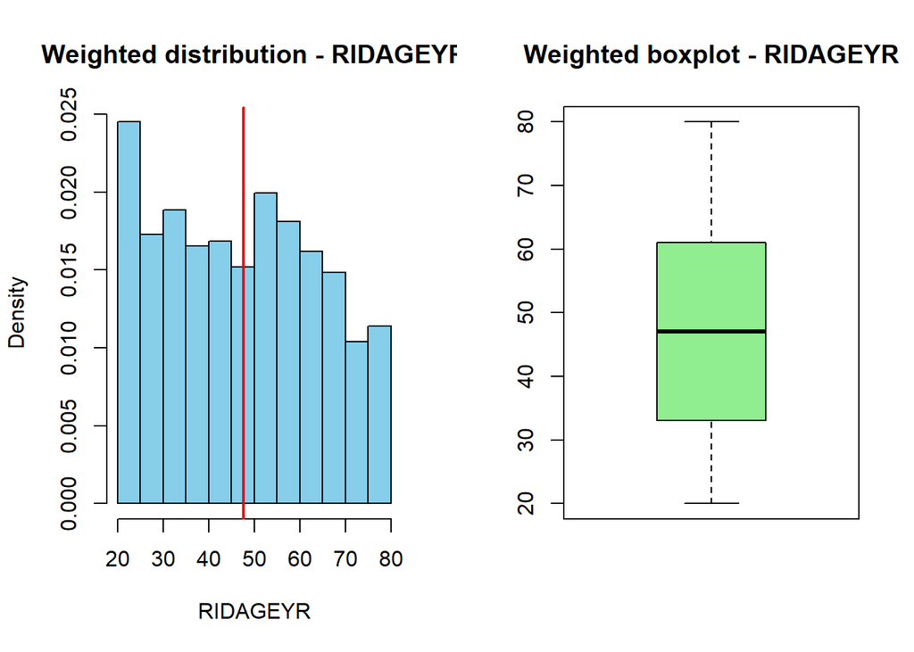

```
##
## --- RIDAGEYR ---
## Weighted mean: 47.58295
## Weighted standard deviation: 17.11106
## Weighted skewness: 0.1284479
## Weighted kurtosis: 1.909843
```

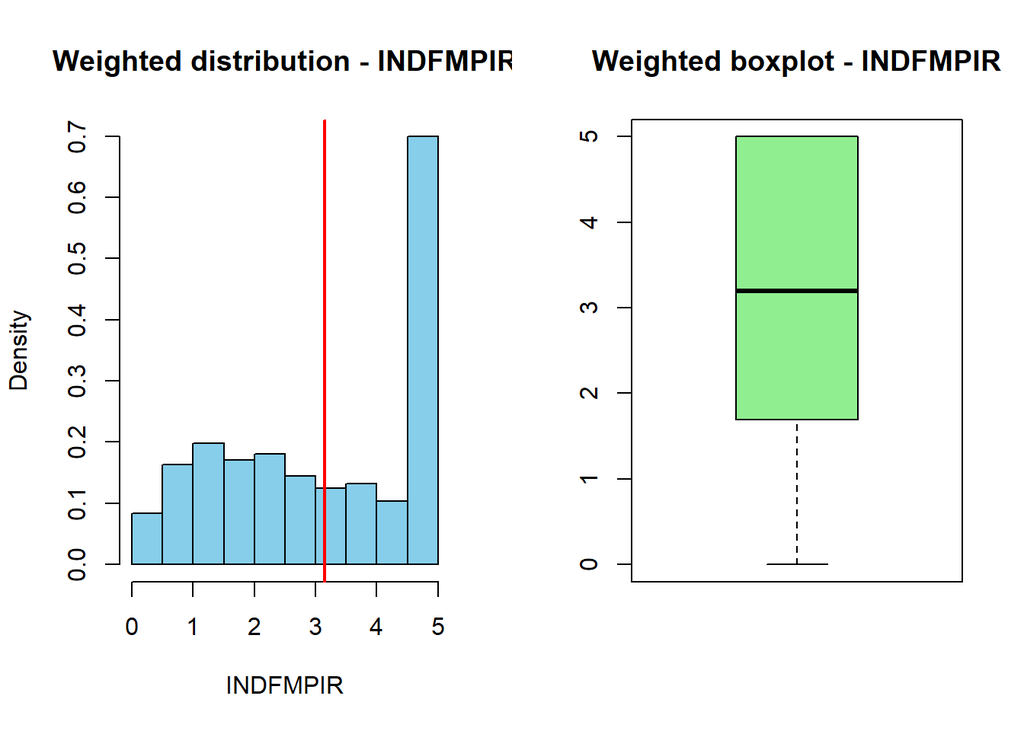

```
##
## --- INDFMPIR ---
## Weighted mean: 3.152457
## Weighted standard deviation: 1.629374
## Weighted skewness: -0.2223334
## Weighted kurtosis: 1.595287
```

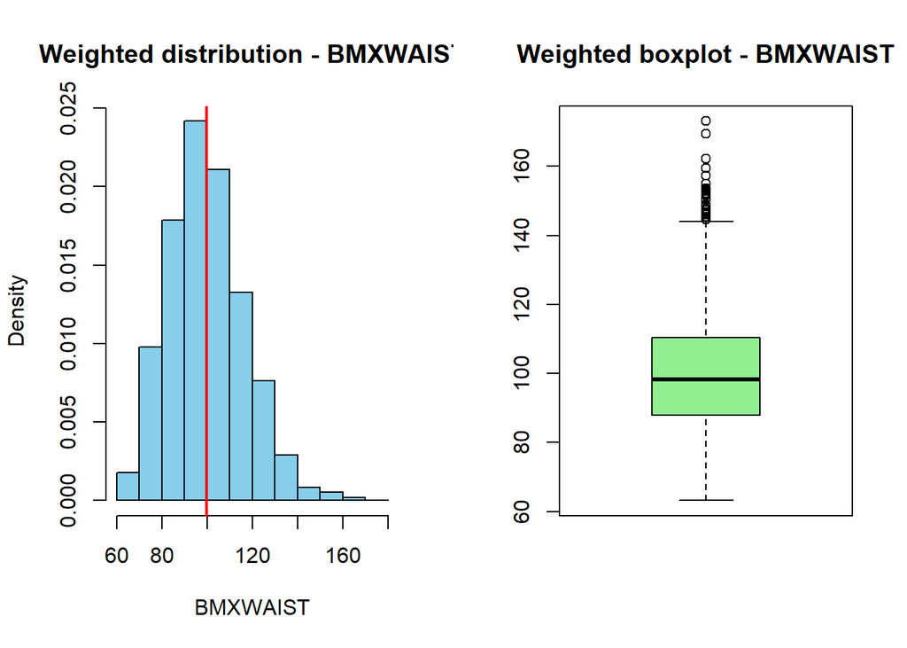

```
##
## --- BMXWAIST ---
## Weighted mean: 99.8175
## Weighted standard deviation: 16.69327
## Weighted skewness: 0.5176967
## Weighted kurtosis: 3.355534
```

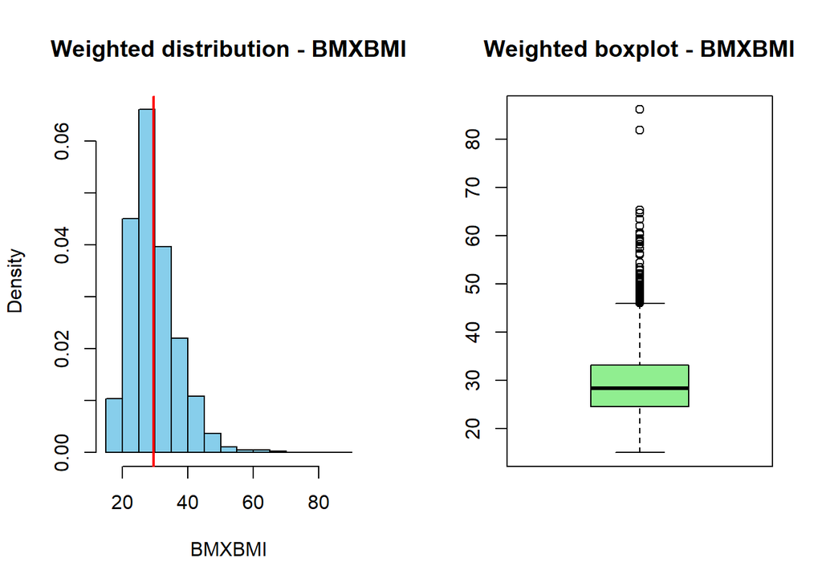

```
##
## --- BMXBMI ---
## Weighted mean: 29.5428
## Weighted standard deviation: 7.121892
## Weighted skewness: 1.204086
## Weighted kurtosis: 5.940754
```

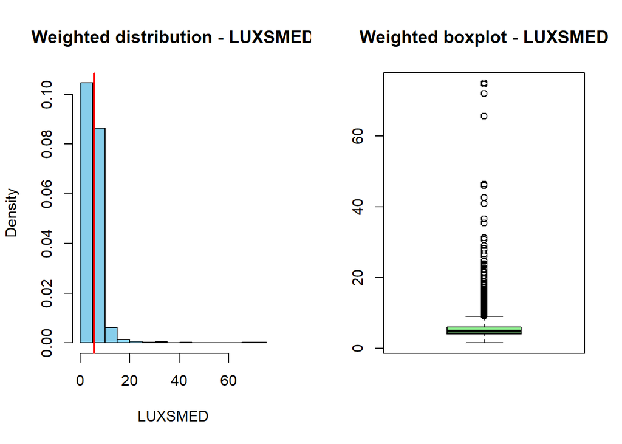

```
##
## --- LUXSMED ---
## Weighted mean: 5.624472
## Weighted standard deviation: 3.905011
## Weighted skewness: 9.164434
## Weighted kurtosis: 127.7707
```

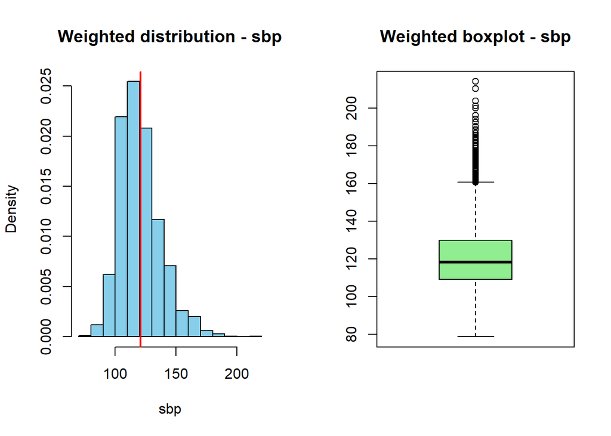

```
##
## --- sbp ---
## Weighted mean: 120.7884
## Weighted standard deviation: 16.8407
## Weighted skewness: 0.9102572
## Weighted kurtosis: 4.456205
```

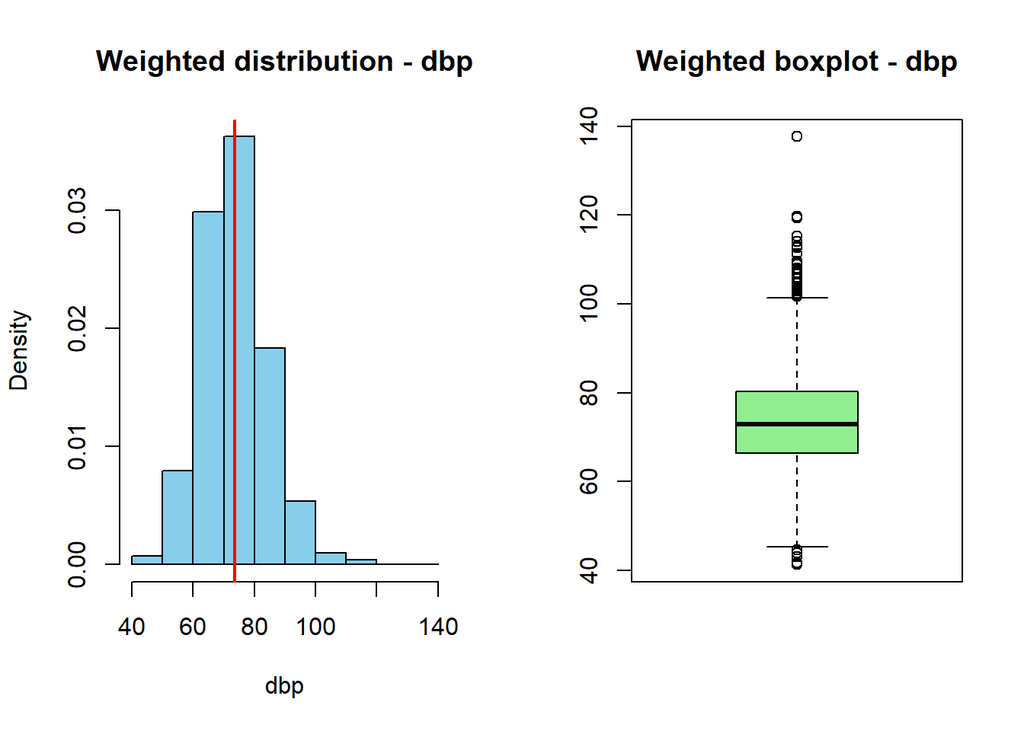

```
##
## --- dbp ---
## Weighted mean: 73.66215
## Weighted standard deviation: 10.81331
## Weighted skewness: 0.4688056
## Weighted kurtosis: 3.881374
```

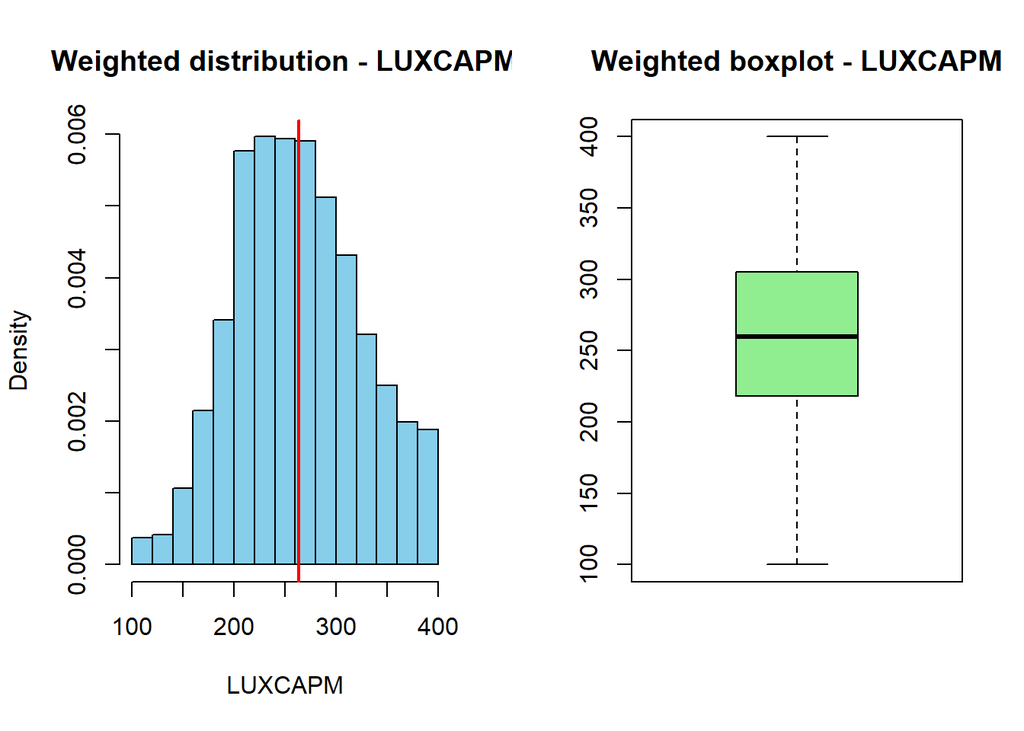

```
##
## --- LUXCAPM ---
## Weighted mean: 263.7916
## Weighted standard deviation: 61.74941
## Weighted skewness: 0.1458275
## Weighted kurtosis: 2.575299
```

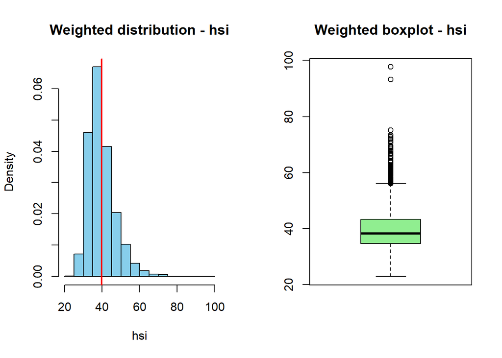

```
##
## --- hsi ---
## Weighted mean: 39.75608
## Weighted standard deviation: 7.255463
## Weighted skewness: 1.256756
## Weighted kurtosis: 6.009142
```

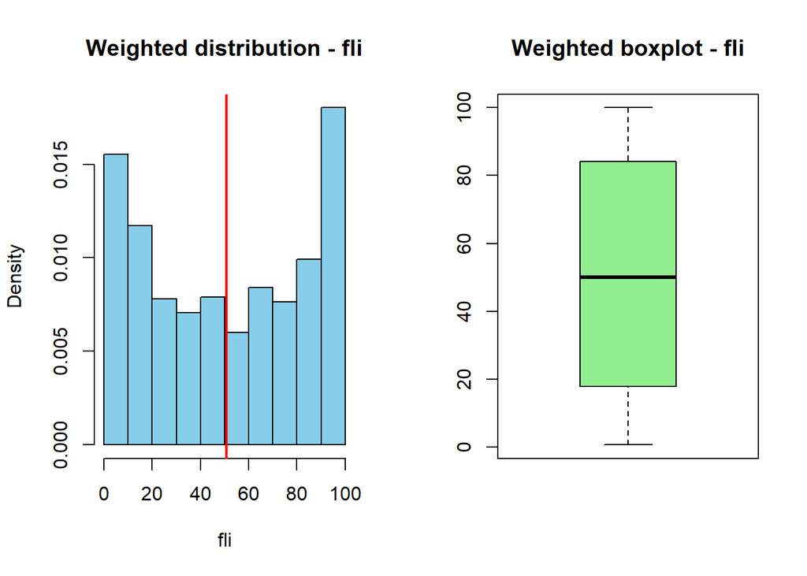

```
##
## --- fli ---
## Weighted mean: 50.71433
## Weighted standard deviation: 33.25801
## Weighted skewness: 0.007903645
## Weighted kurtosis: 1.5357
```

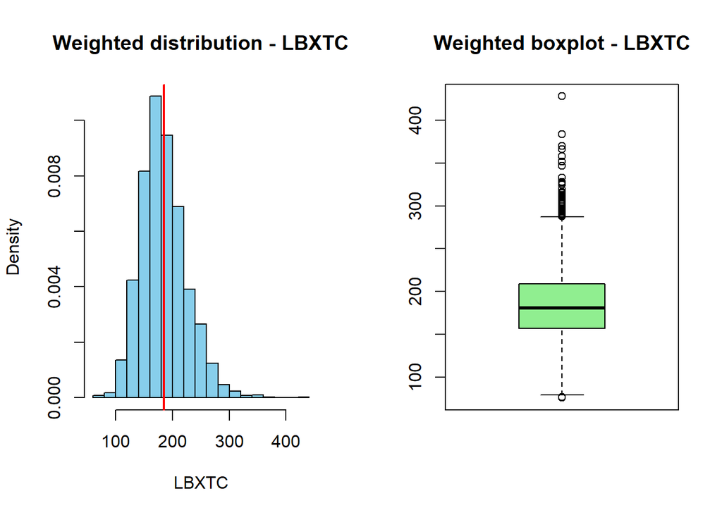

```
##
## --- LBXTC ---
## Weighted mean: 185.245
## Weighted standard deviation: 40.53814
## Weighted skewness: 0.6860603
## Weighted kurtosis: 4.160816
```

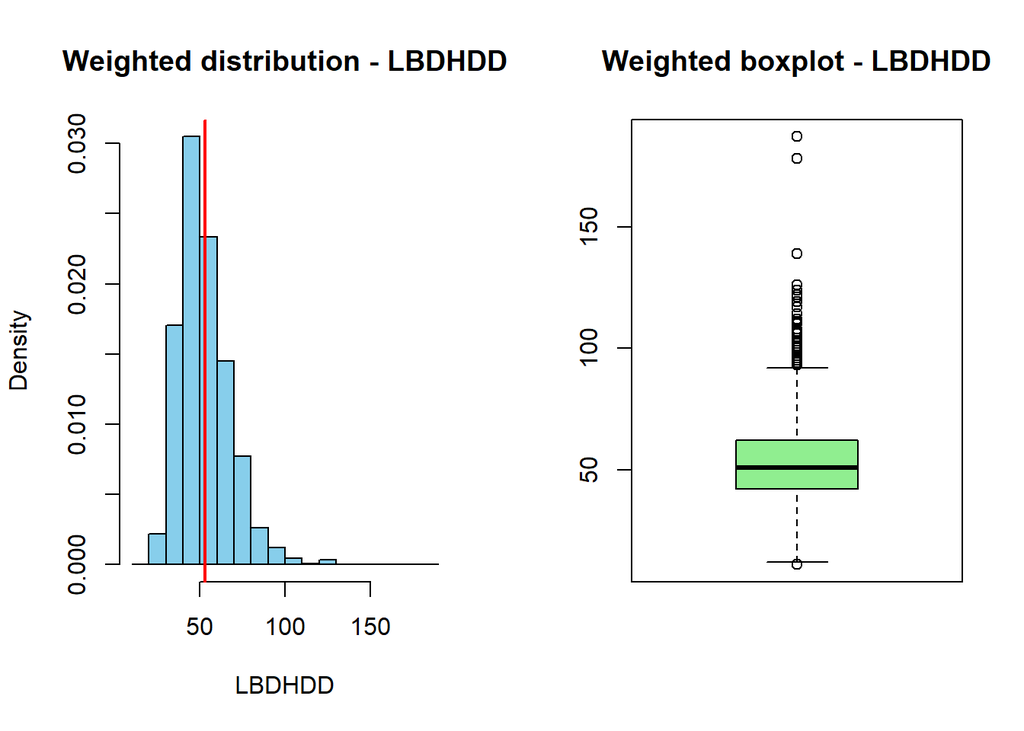

```
##
## --- LBDHDD ---
## Weighted mean: 53.08979
## Weighted standard deviation: 14.9341
## Weighted skewness: 1.068654
## Weighted kurtosis: 5.335897
```

[24 more figures not shown]

```
##
## --- tunsatfat_adj ---
## Weighted mean: 43.17683
## Weighted standard deviation: 13.81928
## Weighted skewness: -0.01175219
## Weighted kurtosis: 6.696125
```

```r
par(mfrow = c(1, 2))

# Numeric variables for analysis, excluding IDs and weights
df_vars <- names(svy_design_subset$variables)[
  sapply(svy_design_subset$variables, is.numeric)
]
vars_to_analyze <- setdiff(df_vars, c("SEQN", "WTSAFPRP", "SDMVPSU", "SDMVSTRA"))

par(mfrow = c(1, 2)) # Two plots side by side

for (var in vars_to_analyze) {

  # Formulas for histogram and boxplot
  f_hist <- as.formula(paste0("~", var))
  f_box  <- as.formula(paste0(var, " ~ 1"))

  # Weighted mean and standard deviation
  mean_val <- as.numeric(coef(svymean(
    f_hist, svy_design_subset, na.rm = TRUE
  )))
  sd_val <- sqrt(svyvar(f_hist, svy_design_subset, na.rm = TRUE))

  # Weighted histogram
  svyhist(
    f_hist,
    design = svy_design_subset,
    main = paste("Weighted distribution -", var),
    xlab = var,
    col = "skyblue",
    border = "black"
  )
  abline(v = mean_val, col = "red", lwd = 2)

  # Weighted boxplot
  svyboxplot(
    f_box,
    svy_design_subset,
    main = paste("Weighted boxplot -", var),
    col = "lightgreen",
    all.outliers = TRUE
  )

  # Weighted skewness and kurtosis
  x <- svy_design_subset$variables[[var]]
  w <- weights(svy_design_subset)
  valid <- !is.na(x) & !is.na(w)
  x <- x[valid]
  w <- w[valid]

  m2 <- sum(w * (x - mean_val)^2) / sum(w)
  m3 <- sum(w * (x - mean_val)^3) / sum(w)
  m4 <- sum(w * (x - mean_val)^4) / sum(w)

  skew <- m3 / (m2^(3/2))
  kurt <- m4 / (m2^2)

  # Print results
  cat("\n---", var, "---\n")
  cat("Weighted mean:", mean_val, "\n")
  cat("Weighted standard deviation:", sd_val, "\n")
  cat("Weighted skewness:", skew, "\n")
  cat("Weighted kurtosis:", kurt, "\n")
}
```

*NOTE* Skewness: ideally between −1 and +1, preferably between −0.5 and +0.5. *NOTE* Raw kurtosis: ideally between 2 and 4, preferably between 2.5 and 3.5.

Interpretation:

Skewness ≈ 0: approximately symmetric distribution. Skewness > 0: right-skewed distribution, with a longer upper tail. Skewness < 0: left-skewed distribution, with a longer lower tail. Kurtosis ≈ 3: similar to a normal distribution. Kurtosis < 3: more platykurtic (flatter distribution). Kurtosis > 3: more leptokurtic (greater concentration and/or heavier tails).

These ranges are practical descriptive guidelines, not strict criteria for determining whether a variable follows a normal distribution.

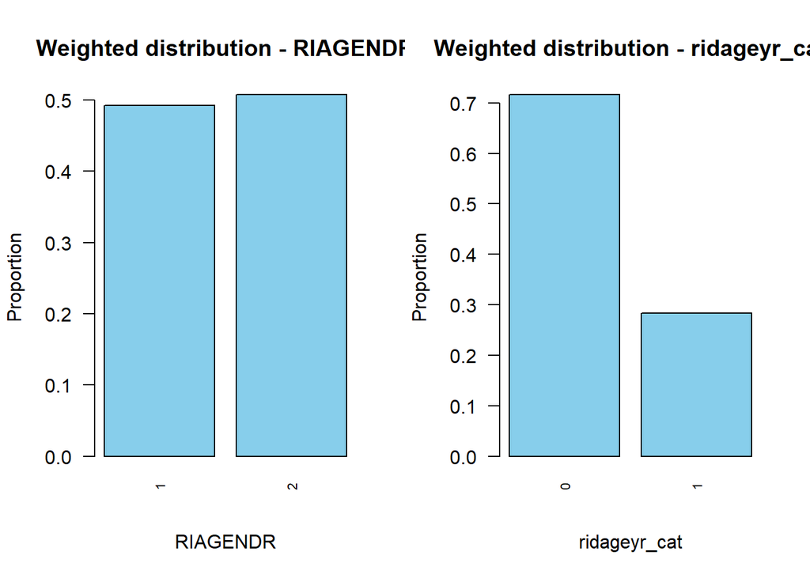

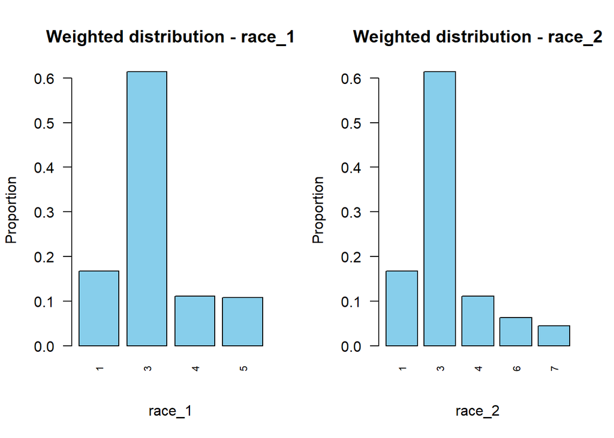

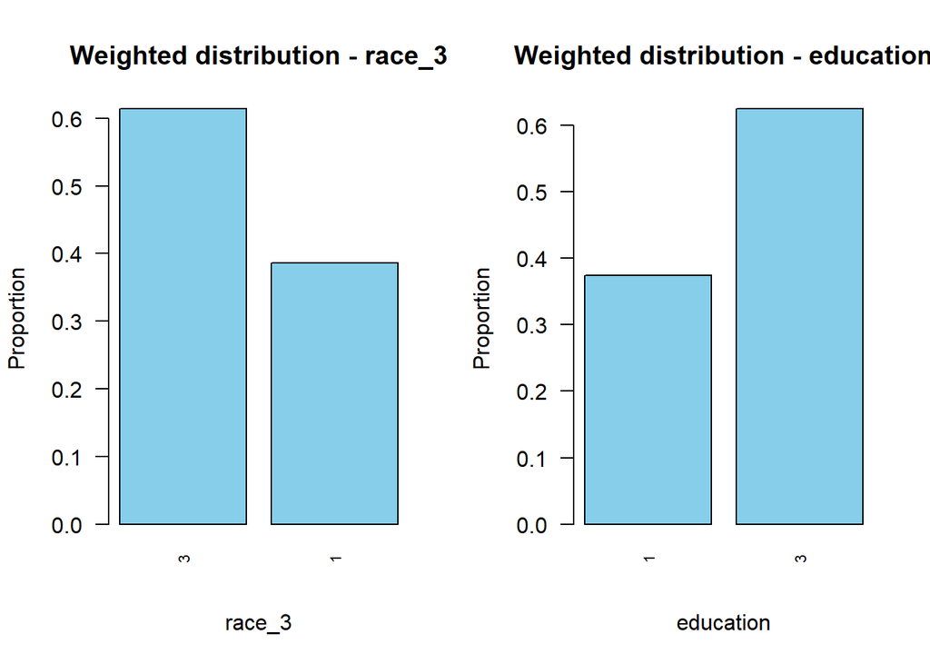

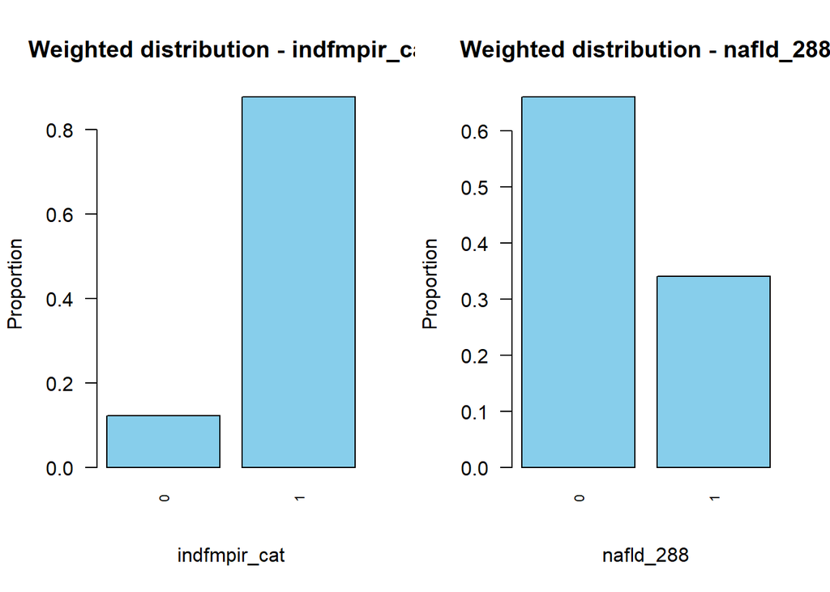

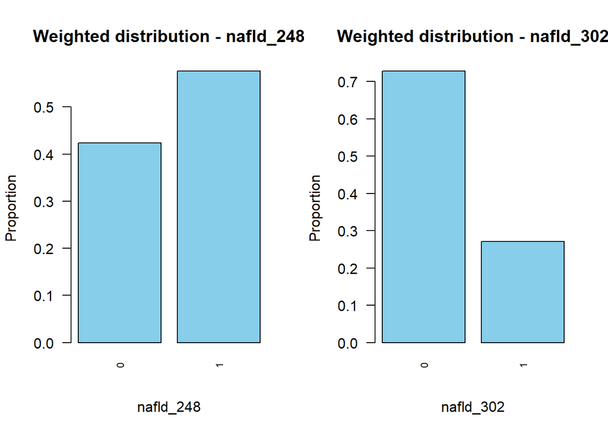

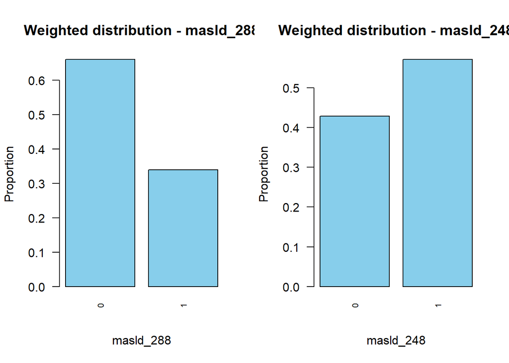

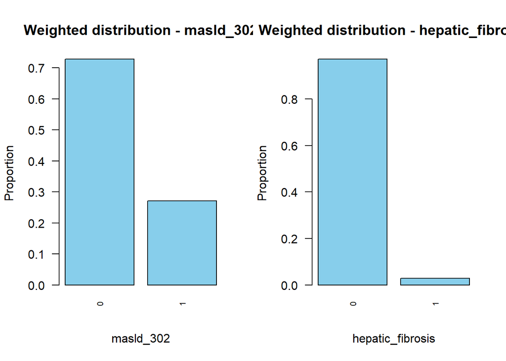

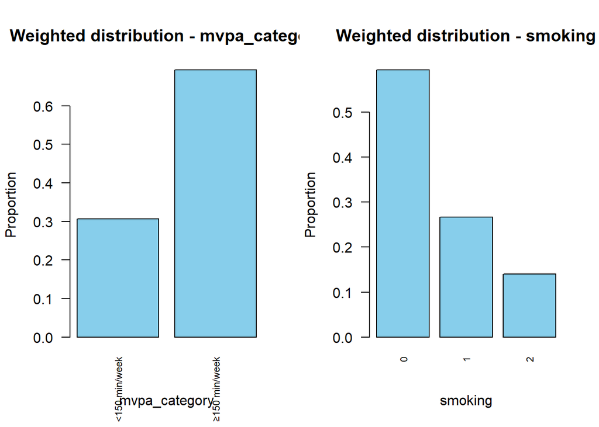

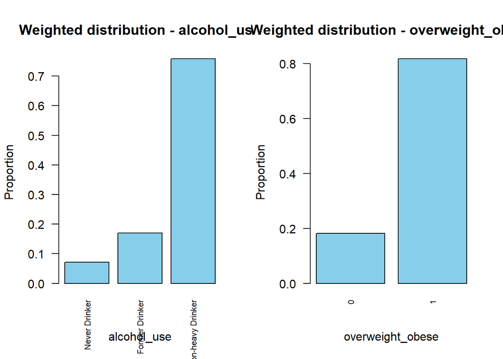

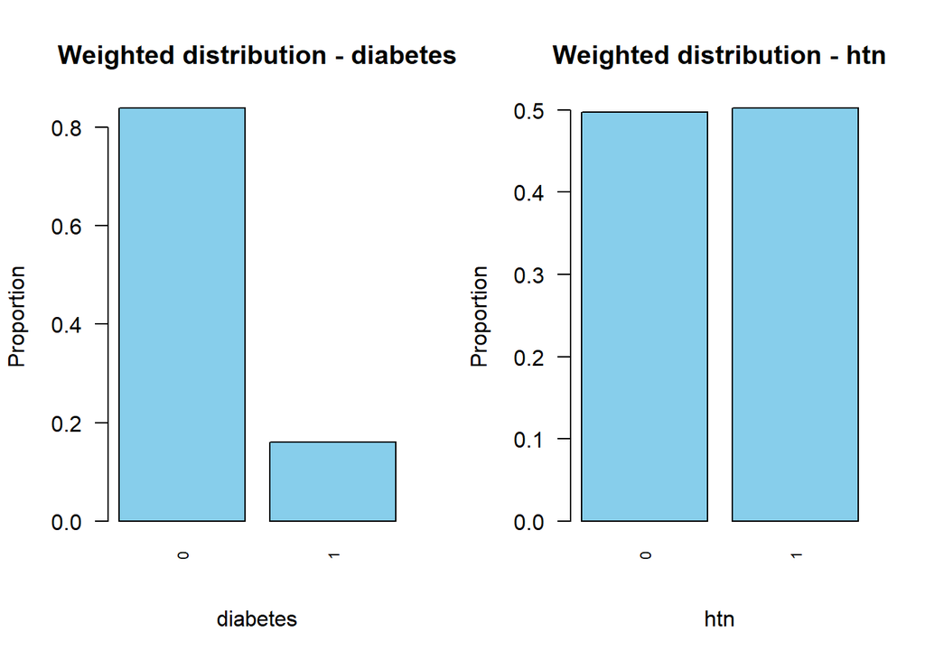

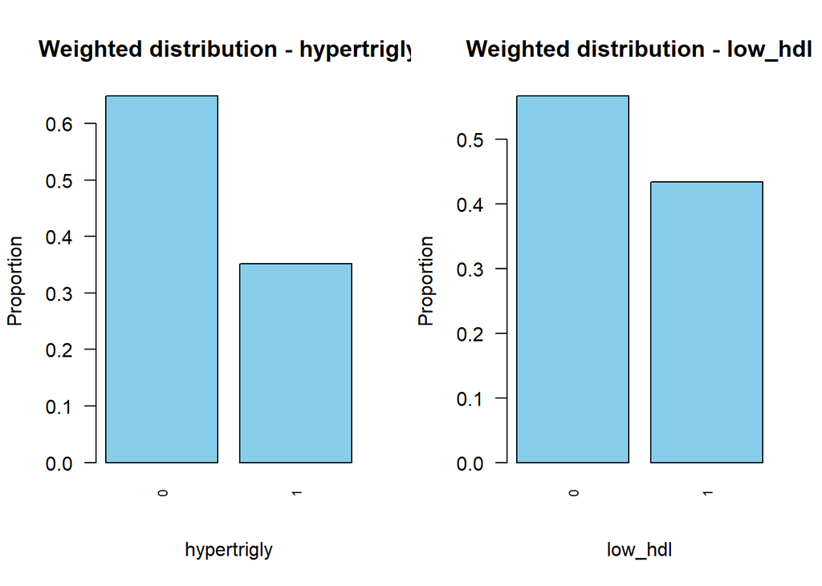

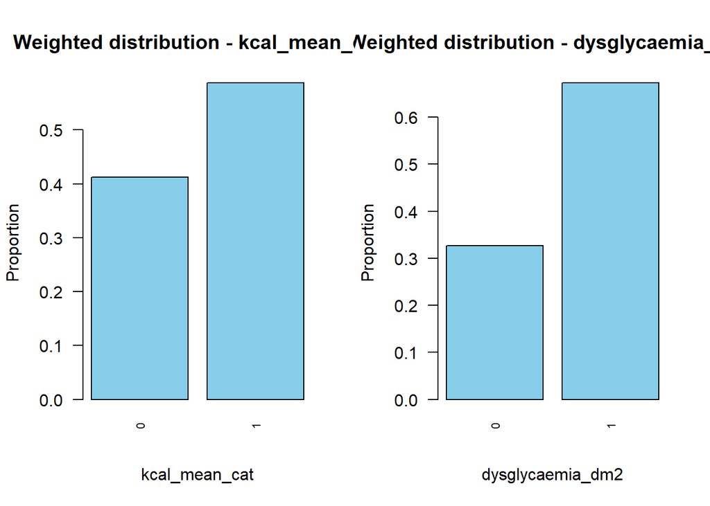

[2 more figures not shown]

```r
par(mfrow = c(1, 2))

# Identify categorical variables (factors or character variables)
cat_vars <- names(svy_design_subset$variables)[
  sapply(svy_design_subset$variables, function(x) is.factor(x) | is.character(x))
]

# Generate weighted bar plots
for (var in cat_vars) {

  # Create weighted frequency table
  tbl <- svytable(
    as.formula(paste0("~", var)),
    svy_design_subset,
    Ntotal = 1
  )

  # Prepare title and labels
  main_txt <- paste("Weighted distribution -", var)
  xlab_txt <- var
  ylab_txt <- "Proportion"

  # Generate bar plot
  barplot(
    tbl,
    main = main_txt,
    xlab = xlab_txt,
    ylab = ylab_txt,
    cex.names = 0.7,
    col = "skyblue",
    border = "black",
    las = 2
  )

}
```

# 4. Descriptive Statistics of the Study Sample

```r
descriptive_vars <- c(

  # Demográficas
  "RIDAGEYR", "RIAGENDR", "race_3", "education", "INDFMPIR",

  # Antropométricas
  "BMXBMI", "BMXWAIST", "overweight_obese",

  # Pressão arterial
  "sbp", "dbp", "htn",

  # Lipídeos
  "LBXTC", "LBDHDD", "LBDLDL", "LBXTR", "low_hdl", "dyslipidemia",

  # Glicose
  "LBXGLU", "LBXGH", "dysglycaemia_dm2",

  # Estilo de vida
  "kcal_mean", "tsugar_adj", "tsatfat_adj", "smoking", "alcohol_use",

  # Atividade física
  "mvpa_category", "PAD680",

  # Desfechos hepáticos
  "LUXCAPM", "LUXSMED", "masld_288", "hepatic_fibrosis"
)

# Criar um vetor nomeado com os rótulos personalizados
custom_labels <- list(

  # Demographic
  RIDAGEYR = "Age (years)",
  RIAGENDR = "Sex, Male",
  race_3 = "Race/Ethnicity",
  education = "Educational level",
  INDFMPIR = "Income-to-Poverty Ratio",

  # Anthropometric
  BMXBMI = "BMI (kg/m²)",
  BMXWAIST = "Waist circumference (cm)",
  overweight_obese = "Overweight/Obesity",

  # Blood pressure
  sbp = "SBP (mmHg)",
  dbp = "DBP (mmHg)",
  htn = "Hypertension",

  # Lipids
  LBXTC = "Total cholesterol (mg/dL)",
  LBDLDL = "LDL-C (mg/dL)",
  LBDHDD = "HDL-C (mg/dL)",
  LBXTR = "Triglycerides (mg/dL)",
  low_hdl = "Low HDL-C",
  dyslipidemia = "Dyslipidemia",

  # Glucose
  LBXGLU = "Fasting glucose (mg/dL)",
  LBXGH = "HbA1c (%)",
  dysglycaemia_dm2 = "Prediabetes/Diabetes",

  # Lifestyle
  kcal_mean = "Total energy intake (kcal/day)",
  tsugar_adj = "Sugar intake",
  tsatfat_adj = "Saturated fat intake",
  smoking = "Smoking",
  alcohol_use = "Alcohol use",

  # Physical activity
  mvpa_category = "Physical activity (≥150 min/week)",
  PAD680 = "Sedentary behavior (min/day)",

  # Liver outcomes
  LUXCAPM = "CAP (dB/m)",
  LUXSMED = "Liver stiffness (kPa)",
  masld_288 = "MASLD",
  hepatic_fibrosis = "Advanced liver fibrosis"

)
```

```r
# ==============================================================================
# SURVEY-WEIGHTED DESCRIPTIVE TABLE
# ==============================================================================

# Total unweighted sample size
n_total <- nrow(svy_design_subset$variables)

descriptive_tbl_weighted <- svy_design_subset %>%
  tbl_svysummary(
    by = !!rlang::sym("masld_288"),
    include = c(all_of(descriptive_vars), -masld_288),
    missing = "no",
    label = custom_labels,
    statistic = list(
      all_continuous() ~ "{mean} ± {sd}",
      all_dichotomous() ~ "{n_unweighted} ({p}%)",
      all_categorical() ~ "{n_unweighted} ({p}%)"
    ),
    type = list(
      c(
        RIAGENDR, overweight_obese, low_hdl,
        dysglycaemia_dm2, htn, hepatic_fibrosis,
        mvpa_category
      ) ~ "dichotomous",
      c("race_3", "education", "smoking") ~ "categorical"
    ),
    value = list(
      RIAGENDR ~ "1",
      overweight_obese ~ "1",
      low_hdl ~ "1",
      dysglycaemia_dm2 ~ "1",
      htn ~ "1",
      hepatic_fibrosis ~ "1",
      mvpa_category ~ "≥150 min/week"
    )
  ) %>%
  add_overall(
    last = FALSE,
    col_label = glue::glue("**All Participants**<br>n = {n_total}")
  ) %>%
  # Dynamic headers: {level} + unweighted sample size
  modify_header(
    label ~ "**Variables**",
    all_stat_cols() ~ "**{level}**<br>n = {n_unweighted}",
    stat_1 ~ "**Control**<br>n = {n_unweighted}",
    stat_2 ~ "**MASLD**<br>n = {n_unweighted}"
  ) %>%
  # Dynamic spanning header
  modify_spanning_header(
    starts_with("stat_") ~ "**MASLD Status**"
  ) %>%
  modify_caption(
    "**Table 1. Survey-Weighted Baseline Characteristics of U.S. Adults Stratified by MASLD (CAP ≥288 dB/m)**"
  ) %>%
  bold_labels() %>%
  modify_footnote(
    update = all_stat_cols() ~ paste(
      "Data presented as unweighted n and weighted percentage (%) for categorical variables,",
      "and mean ± standard deviation for continuous variables. Estimates are weighted to be representative of the",
      "non-institutionalized U.S. adult population using NHANES fasting subsample weights and",
      "accounting for the complex survey design. Weighted sample size: n = {N}.",
      "CAP = Controlled Attenuation Parameter; MASLD = Metabolic dysfunction-associated steatotic liver disease;",
      "MVPA = Moderate-to-Vigorous Physical Activity; BP = Blood Pressure;",
      "HDL-C = High-Density Lipoprotein Cholesterol; LDL-C = Low-Density Lipoprotein Cholesterol."
    )
  )

# Display table
descriptive_tbl_weighted
```

**Table 1. Survey-Weighted Baseline Characteristics of U.S. Adults Stratified by MASLD (CAP ≥288 dB/m)**

| **Variables** | **MASLD Status** **Overall** n = 3034<sup>1</sup> | **MASLD Status** **Control** n = 1965<sup>1</sup> | **MASLD Status** **MASLD** n = 1069<sup>1</sup> |
| --- | --- | --- | --- |
| Age (years) | 48 ± 17 | 46 ± 17 | 51 ± 16 |
| Sex, Male | 1,454 (49%) | 883 (46%) | 571 (56%) |
| Race/Ethnicity |  |  |  |
| 3 | 999 (61%) | 617 (61%) | 382 (62%) |
| 1 | 2,035 (39%) | 1,348 (39%) | 687 (38%) |
| Educational level |  |  |  |
| 1 | 1,282 (37%) | 787 (35%) | 495 (43%) |
| 3 | 1,750 (63%) | 1,177 (65%) | 573 (57%) |
| Income-to-Poverty Ratio | 3.15 ± 1.63 | 3.21 ± 1.63 | 3.04 ± 1.62 |
| BMI (kg/m²) | 30 ± 7 | 27 ± 6 | 34 ± 7 |
| Waist circumference (cm) | 100 ± 17 | 93 ± 14 | 112 ± 15 |
| Overweight/Obesity | 2,511 (82%) | 1,469 (74%) | 1,042 (98%) |
| SBP (mmHg) | 121 ± 17 | 119 ± 17 | 124 ± 17 |
| DBP (mmHg) | 74 ± 11 | 72 ± 10 | 77 ± 11 |
| Hypertension | 1,631 (50%) | 909 (40%) | 722 (69%) |
| Total cholesterol (mg/dL) | 185 ± 41 | 184 ± 40 | 187 ± 42 |
| HDL-C (mg/dL) | 53 ± 15 | 57 ± 15 | 46 ± 12 |
| LDL-C (mg/dL) | 110 ± 35 | 110 ± 34 | 112 ± 38 |
| Triglycerides (mg/dL) | 111 ± 95 | 92 ± 80 | 149 ± 109 |
| Low HDL-C | 1,396 (43%) | 739 (35%) | 657 (60%) |
| Dyslipidemia |  |  |  |
| 0 | 902 (32%) | 717 (40%) | 185 (18%) |
| 1 | 2,093 (68%) | 1,217 (60%) | 876 (82%) |
| Fasting glucose (mg/dL) | 110 ± 32 | 103 ± 21 | 123 ± 44 |
| HbA1c (%) | 5.69 ± 0.95 | 5.48 ± 0.68 | 6.09 ± 1.24 |
| Prediabetes/Diabetes | 2,154 (67%) | 1,223 (58%) | 931 (85%) |
| Total energy intake (kcal/day) | 2,064 ± 804 | 2,037 ± 796 | 2,115 ± 819 |
| Sugar intake | 89 ± 45 | 90 ± 44 | 88 ± 46 |
| Saturated fat intake | 24 ± 8 | 24 ± 8 | 25 ± 9 |
| Smoking |  |  |  |
| 0 | 1,841 (59%) | 1,228 (60%) | 613 (58%) |
| 1 | 714 (27%) | 414 (25%) | 300 (30%) |
| 2 | 477 (14%) | 321 (15%) | 156 (12%) |
| Alcohol use |  |  |  |
| Never Drinker | 283 (7.1%) | 186 (6.6%) | 97 (8.2%) |
| Former Drinker | 612 (17%) | 372 (16%) | 240 (20%) |
| Non-heavy Drinker | 1,992 (76%) | 1,317 (78%) | 675 (72%) |
| Physical activity (≥150 min/week) | 1,925 (69%) | 1,290 (73%) | 635 (63%) |
| Sedentary behavior (min/day) | 354 ± 206 | 339 ± 195 | 382 ± 222 |
| CAP (dB/m) | 264 ± 62 | 228 ± 39 | 333 ± 33 |
| Liver stiffness (kPa) | 5.62 ± 3.91 | 5.01 ± 2.83 | 6.82 ± 5.22 |
| Advanced liver fibrosis | 92 (2.9%) | 29 (0.9%) | 63 (6.7%) |

<sup>1</sup> Data presented as unweighted n and weighted percentage (%) for categorical variables, and mean ± standard deviation for continuous variables. Estimates are weighted to be representative of the non-institutionalized U.S. adult population using NHANES fasting subsample weights and accounting for the complex survey design. Weighted sample size: n = 195963922.954713. CAP = Controlled Attenuation Parameter; MASLD = Metabolic dysfunction-associated steatotic liver disease; MVPA = Moderate-to-Vigorous Physical Activity; BP = Blood Pressure; HDL-C = High-Density Lipoprotein Cholesterol; LDL-C = Low-Density Lipoprotein Cholesterol.

```r
# Export table
gtsave(
  as_gt(descriptive_tbl_weighted),
  here("Tables", "descriptive_table_weighted.docx")
)

gtsave(
  as_gt(descriptive_tbl_weighted),
  here("Tables", "descriptive_table_weighted.pdf")
)
```

**Note:** If a variable is a factor with exactly two levels labeled “Yes” and “No”, `tbl_summary()` by default displays only the row corresponding to “Yes”. The same applies to variables with `TRUE/FALSE` or `1/0` values. Use the `value` argument to specify the displayed level (see `?gtsummary::tbl_summary`). Alternatively, set `type` to `"categorical"` to display all levels.

**Note:** P-values are not included in Table 1. The primary purpose of a descriptive table is to summarize the characteristics and distributions of the study population rather than to formally test differences between groups. P-values are highly dependent on sample size and may identify statistically significant differences that are not clinically meaningful, particularly in large samples. Confounding should be assessed based on prior knowledge and causal considerations rather than statistical significance alone (Vandenbroucke et al., 2007; Moher et al., 2010, https://bookdown.org/rwnahhas/RMPH/datasumm-table1.html).